# R Notebook: data-intro

Peyton Urquhart [peyton.urquhart]

#### Search machine for Python

I couldn’t get some Python packages to load.. Need to read up on virtualenv. I will keep the initial setup to try for the next assignment.

```r
reticulate::py_config();
```

```
## python:         C:/Users/peyton.urquhart/AppData/Local/Programs/Python/Python39/python.exe
## libpython:      C:/Users/peyton.urquhart/AppData/Local/Programs/Python/Python39/python39.dll
## pythonhome:     C:/Users/peyton.urquhart/AppData/Local/Programs/Python/Python39
## version:        3.9.2 (tags/v3.9.2:1a79785, Feb 19 2021, 13:44:55) [MSC v.1928 64 bit (AMD64)]
## Architecture:   64bit
## numpy:           [NOT FOUND]
##
## python versions found:
##  C:/Users/peyton.urquhart/AppData/Local/Programs/Python/Python39/python.exe
##  C:/Program Files (x86)/Microsoft Visual Studio/Shared/Python37_64/python.exe
```

#### Was Python Found ?

```
## [1] "SUCCESS: python installation found"
```

#### Local or Remote ?

```r
which.github = "local";
#which.github = "remote";
```

```r
loadDataIMDB();
```

## Will Smith

Build a dataframe “will.df” for Will Smith with 2 primary sections:

will.df$info containing a single row of information about Will Smith.

will.df$movies containing a large dataframe where each row represents one of Will Smiths movies.

```r
will.df <- list(movies = IMDB.getMoviesForPerson("nm0000226"), info = IMDB.getPersonInfo("nm0000226"));
will.df$movies;
```

|  | ttid | nmid | rank | year | title | genre | rated | minutes | ratings | metacritic | votes | millions | paragraph |
| --- | --- | --- | --- | --- | --- | --- | --- | --- | --- | --- | --- | --- | --- |
| 39 | tt0480249 | nm0000226 | 1 | 2007 | I Am Legend | Action, Adventure, Drama | PG-13 | 101 | 7.2 | 65 | 675160 | 256.39 | Years after a plague kills most of humanity and transforms the rest into monsters, the sole survivor in New York City struggles valiantly to find a cure in this post-apocalyptic action thriller. |
| 65 | tt1386697 | nm0000226 | 2 | 2016 | Suicide Squad | Action, Adventure, Fantasy | PG-13 | 123 | 6.0 | 40 | 588064 | 325.10 | A secret government agency recruits some of the most dangerous incarcerated super-villains to form a defensive task force. Their first mission: save the world from the apocalypse. |
| 6 | tt0116629 | nm0000226 | 3 | 1996 | Independence Day | Action, Adventure, Sci-Fi | PG-13 | 145 | 7.0 | 59 | 520592 | 306.17 | The aliens are coming and their goal is to invade and destroy Earth. Fighting superior technology, mankind's best weapon is the will to survive. |
| 7 | tt0119654 | nm0000226 | 4 | 1997 | Men in Black | Action, Adventure, Comedy | PG-13 | 98 | 7.3 | 71 | 507597 | 250.69 | A police officer joins a secret organization that polices and monitors extraterrestrial interactions on Earth. |
| 26 | tt0343818 | nm0000226 | 5 | 2004 | I, Robot | Action, Drama, Sci-Fi | PG-13 | 115 | 7.1 | 59 | 491474 | 144.80 | In 2035, a technophobic cop investigates a crime that may have been perpetrated by a robot, which leads to a larger threat to humanity. |
| 35 | tt0454921 | nm0000226 | 6 | 2006 | The Pursuit of Happyness | Biography, Drama | PG-13 | 117 | 8.0 | 64 | 438121 | 163.57 | A struggling salesman takes custody of his son as he's poised to begin a life-changing professional career. |
| 34 | tt0448157 | nm0000226 | 7 | 2008 | Hancock | Action, Fantasy | PG-13 | 92 | 6.4 | 49 | 437887 | 227.95 | Hancock is a superhero whose ill-considered behavior regularly causes damage in the millions. He changes when the person he saves helps him improve his public image. |
| 12 | tt0120912 | nm0000226 | 8 | 2002 | Men in Black II | Action, Adventure, Comedy | PG-13 | 88 | 6.2 | 49 | 337458 | 190.42 | Agent J is sent to find Agent K and restore his memory after the re-appearance of a case from K's past. |
| 66 | tt1409024 | nm0000226 | 9 | 2012 | Men in Black 3 | Action, Adventure, Comedy | PG-13 | 106 | 6.8 | 58 | 329948 | 179.02 | Agent J travels in time to M.I.B.'s early days in 1969 to stop an alien from assassinating his friend Agent K and changing history. |
| 31 | tt0386588 | nm0000226 | 10 | 2005 | Hitch | Comedy, Romance | PG-13 | 118 | 6.6 | 58 | 291991 | 179.50 | A smooth-talking man falls for a hardened columnist while helping a shy accountant woo a beautiful heiress. |

[output cut: 101 more lines]

```r
will.df$info;
```

|  | nmid | name | roles | born.when | born.where | died.when | died.where | starmeter.rank | starmeter.delta | bio |
| --- | --- | --- | --- | --- | --- | --- | --- | --- | --- | --- |
| 226 | nm0000226 | Will Smith | Music Department,Actor,Producer | 1968-9-25 | Philadelphia, Pennsylvania, USA | NA | NA | 500 | 67 | Willard Carroll "Will" Smith, Jr. (born September 25, 1968) is an American actor, comedian, producer, rapper, and songwriter. He has enjoyed success in television, film, and music. In April 2007, News… |

## Denzel Washington

Build a dataframe “denzel.df” for Denzel Washington with 2 primary sections:

denzel.df$info containing a single row of information about Denzel.

denzel.df$movies containing a large dataframe where each row represents one of Denzel Washingtons movies.

```r
denzel.df <- list(movies = IMDB.getMoviesForPerson("nm0000243"), info = IMDB.getPersonInfo("nm0000243"));
denzel.df$movies;
```

|  | ttid | nmid | rank | year | title | genre | rated | minutes | ratings | metacritic | votes | millions | paragraph |
| --- | --- | --- | --- | --- | --- | --- | --- | --- | --- | --- | --- | --- | --- |
| 41 | tt0765429 | nm0000243 | 1 | 2007 | American Gangster | Biography, Crime, Drama | R | 157 | 7.8 | 76 | 383980 | 130.16 | An outcast New York City cop is charged with bringing down Harlem drug lord Frank Lucas, whose real life inspired this partly biographical film. |
| 27 | tt0139654 | nm0000243 | 2 | 2001 | Training Day | Crime, Drama, Thriller | R | 122 | 7.7 | 69 | 382022 | 76.63 | A rookie cop spends his first day as a Los Angeles narcotics officer with a rogue detective who isn't what he appears to be. |
| 38 | tt0454848 | nm0000243 | 3 | 2006 | Inside Man | Crime, Drama, Mystery | R | 129 | 7.6 | 76 | 332729 | 88.51 | A police detective, a bank robber, and a high-power broker enter high-stakes negotiations after the criminal's brilliant heist spirals into a hostage situation. |
| 39 | tt0455944 | nm0000243 | 4 | 2014 | The Equalizer | Action, Crime, Thriller | R | 132 | 7.2 | 57 | 326110 | 101.53 | A man believes he has put his mysterious past behind him and has dedicated himself to beginning a new, quiet life, before he meets a young girl under the control of ultra-violent Russian gangsters and… |
| 34 | tt0328107 | nm0000243 | 5 | 2004 | Man on Fire | Action, Crime, Drama | R | 146 | 7.7 | 47 | 324172 | 77.91 | In Mexico City, a former CIA operative swears vengeance on those who committed an unspeakable act against the family he was hired to protect. |
| 55 | tt1907668 | nm0000243 | 6 | 2012 | Flight | Drama, Thriller | R | 138 | 7.3 | 76 | 320297 | 93.77 | An airline pilot saves almost all his passengers on his malfunctioning airliner which eventually crashed, but an investigation into the accident reveals something troubling. |
| 37 | tt0453467 | nm0000243 | 7 | 2006 | Deja Vu | Action, Crime, Sci-Fi | PG-13 | 126 | 7.0 | 59 | 288953 | 64.04 | After a ferry is bombed in New Orleans, an A.T.F. agent joins a unique investigation using experimental surveillance technology to find the bomber, but soon finds himself becoming obsessed with one of… |
| 45 | tt1037705 | nm0000243 | 8 | 2010 | The Book of Eli | Action, Adventure, Drama | R | 118 | 6.9 | 53 | 288652 | 94.84 | A post-apocalyptic tale, in which a lone man fights his way across America in order to protect a sacred book that holds the secrets to saving humankind. |
| 15 | tt0107818 | nm0000243 | 9 | 1993 | Philadelphia | Drama | PG-13 | 125 | 7.7 | 66 | 219940 | 77.32 | When a man with HIV is fired by his law firm because of his condition, he hires a homophobic small time lawyer as the only willing advocate for a wrongful dismissal suit. |
| 52 | tt1599348 | nm0000243 | 10 | 2012 | Safe House | Action, Thriller | R | 115 | 6.7 | 52 | 202460 | 126.37 | A young CIA agent is tasked with looking after a fugitive in a safe house. But when the safe house is attacked, he finds himself on the run with his charge. |

[output cut: 51 more lines]

```r
denzel.df$info;
```

|  | nmid | name | roles | born.when | born.where | died.when | died.where | starmeter.rank | starmeter.delta | bio |
| --- | --- | --- | --- | --- | --- | --- | --- | --- | --- | --- |
| 243 | nm0000243 | Denzel Washington | Actor,Producer,Director | 1954-12-28 | Mount Vernon, New York, USA | NA | NA | 500 | -64 | Denzel Hayes Washington, Jr. was born on December 28, 1954 in Mount Vernon, New York. He is the middle of three children of a beautician mother, Lennis, from Georgia, and a Pentecostal minister father… |

## Common Movies

Search the dataframes for matching ttid(s). Build a new dataframe for each match resulting in a dataframe of movies starring both Will and Denzel

```r
findCommonMovies(will.df$movies, denzel.df$movies);
```

```
## [1] "1 common movie found"
```

|  | ttid | nmid | rank | year | title | genre | rated | minutes | ratings | metacritic | votes | millions | paragraph |
| --- | --- | --- | --- | --- | --- | --- | --- | --- | --- | --- | --- | --- | --- |
| 51 | tt1546668 | nm0000243 | 54 | 2007 | The 100 Best Black Movies (Ever) | Documentary | NA | NA | 5 | NA | NA | NA | Add a Plot |

## Summary

I wrote a higher-order filtering function to filter a dataframe by some function on its columns. For the following summary of genre, only rows with a recorded genre are included.

```r
# Remove all rows where there is a missing value for col #
filterOutMissingValues = function(df, col)
{
  return(filterBy(df, col, (function(x) {!(is.na(x))})))
}
```

### Genre

In these pie-charts for genre, a single movie can appear multiple times in the chart. If the movie has tags “Action” and “Comedy” it will be counted twice.

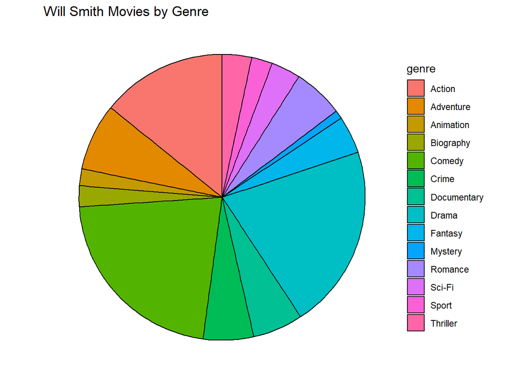

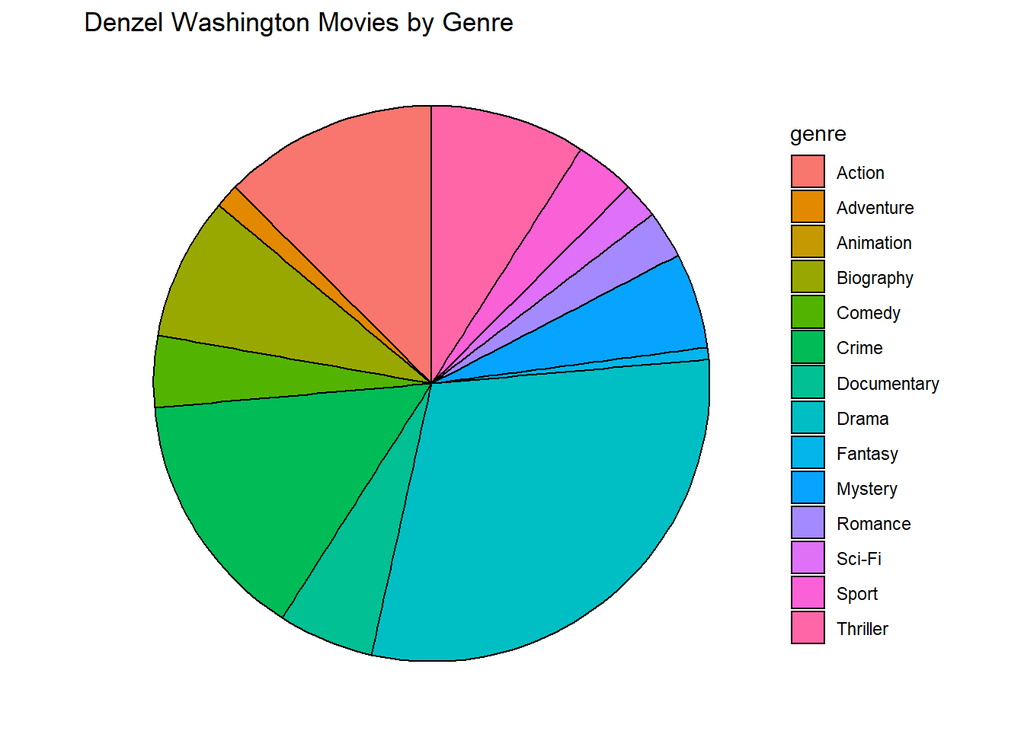

### MPAA Rating

These pie-charts provide a visual for MPAA ratings for Will Smith / Denzel Washington movies.

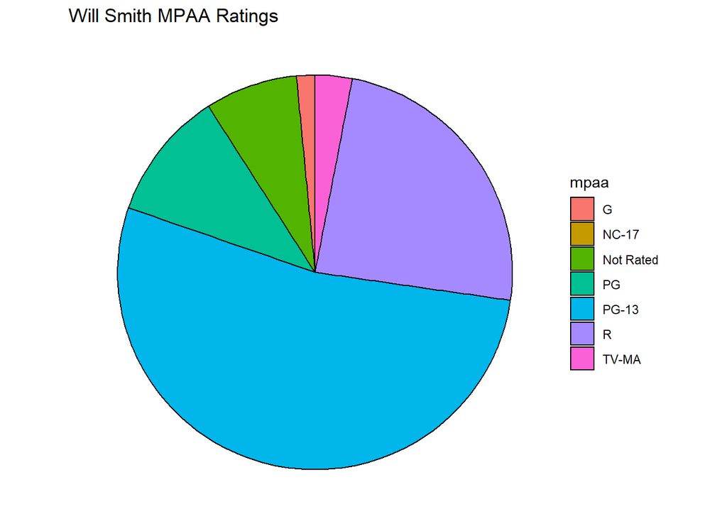

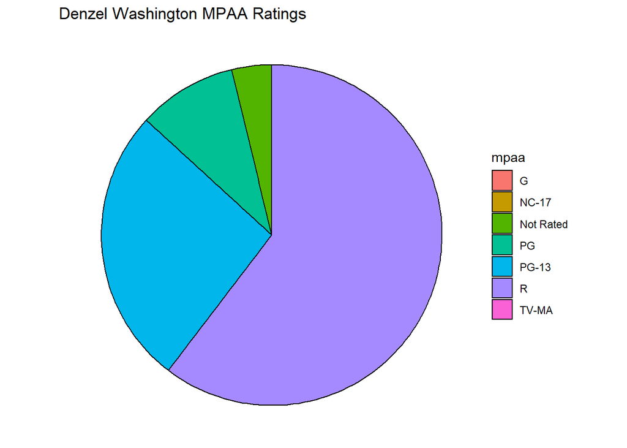

### Average Audience Rating

The average audience ratings for each actor.

| actor | avg.rating |
| --- | --- |
| Will | 6.228378 |
| Denzel | 6.814815 |

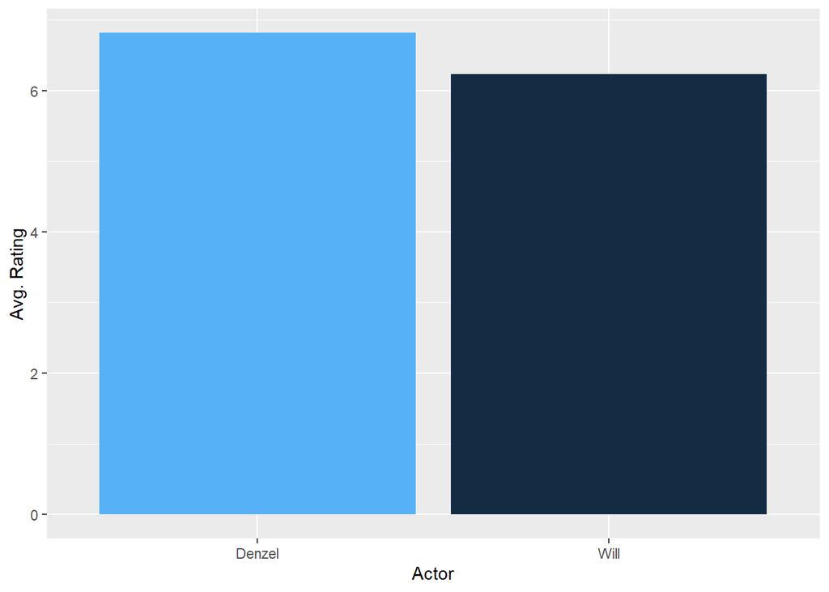